# Kümelerin Seçkisiz Atandığı Çalışmalarda Etki Heterojenliğinin İncelenmesi

Burak AYDIN, James Algina, Walter Leite  
May 2017

### Sunumun Çerçevesi

1. Kümelerin seçkisiz atanması
2. Bölge-Küme ataması(multisite)
3. Model
4. Çözümleme Alternatifleri
5. Simulasyon
6. Sonuçlar
7. Tavsiyeler

### Kümelerin seçkisiz atanması

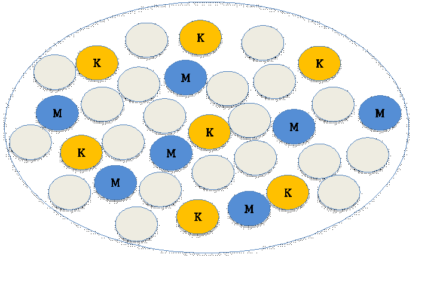

### Bölge-Küme ataması (multisite)

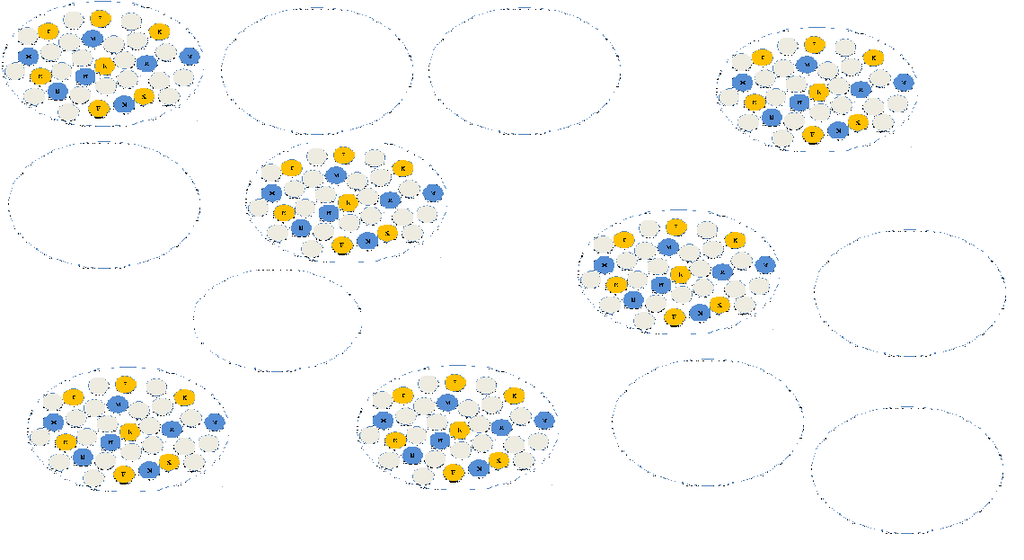

### Model

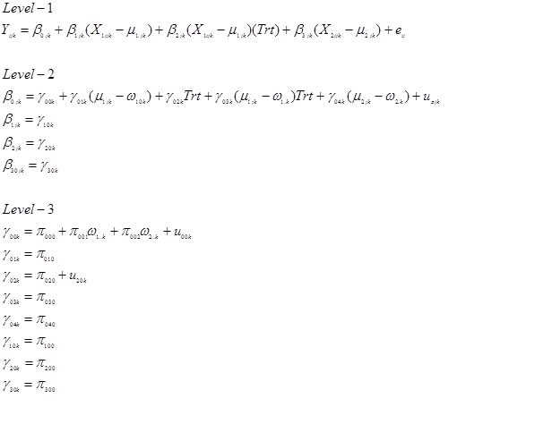

### Çözümleme Alternatifleri-1

Çok düzeyli model Mplus betik

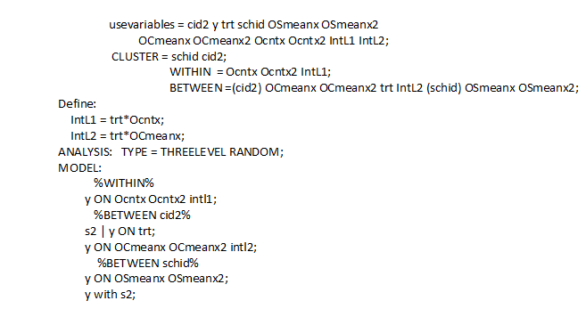

### Çözümleme Alternatifleri-2

Tasarı odaklı model Mplus betik

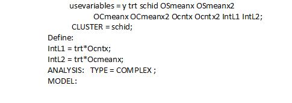

### Simulasyon

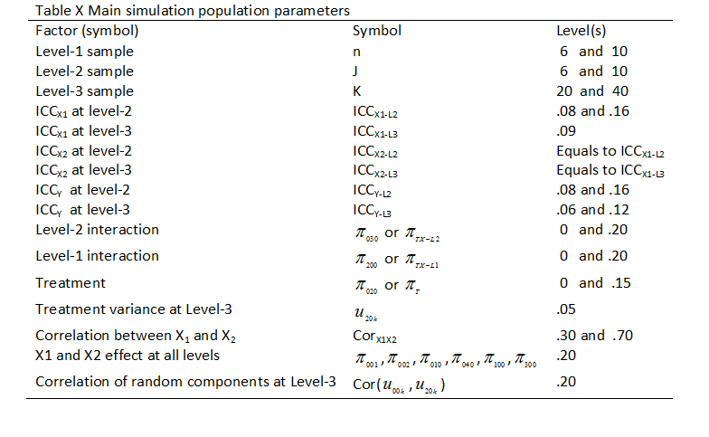

### Sonuçlar

1. Müdahele değişkeni ve birinci düzey etkileşim (interaction) için doğru tahminler, aynı istatistiksel güç ve birinci tip hata oranı

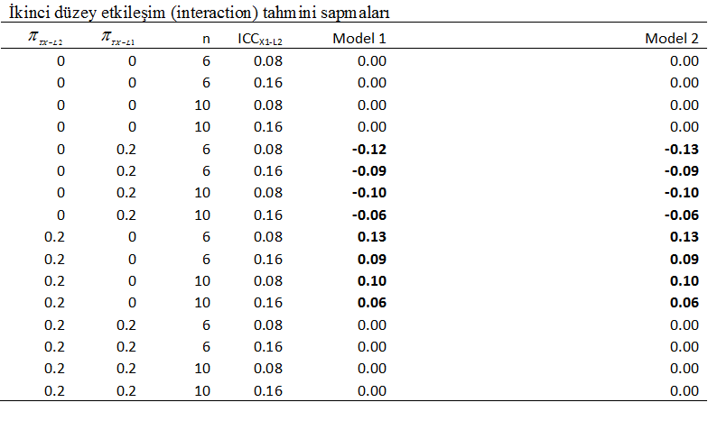

### Tavsiyeler (Simüle edilen şartlar için)

1. Birinci ve ikinci düzeyde etkileşim farklı büyüklükte ise modeller ikinci düzey etkileşim için hatalı tahmin yapıyor.
2. Birinci ve ikinci düzeyde etkileşim benzer büyüklükte ise basit olan model kabul edilir sonuçlar veriyor

### Sunum-2

1. ve 2. sunum ayrıdır.

### Üç Düzeyli Modellerde Birinci Düzey Bağımsız Değişkenin Örtük Ortalamalarının Hesaplanması

Dr. Burak AYDIN

### Sunumun Çerçevesi

1. Üç düzeyli modeller ve örnekler
2. Oluşumsal (formative) ve Yansıtıcı (reflective) ortalamalar
3. Problem-Çözüm
4. Sonuçlar

### Üç düzeyli modeller ve örnekler

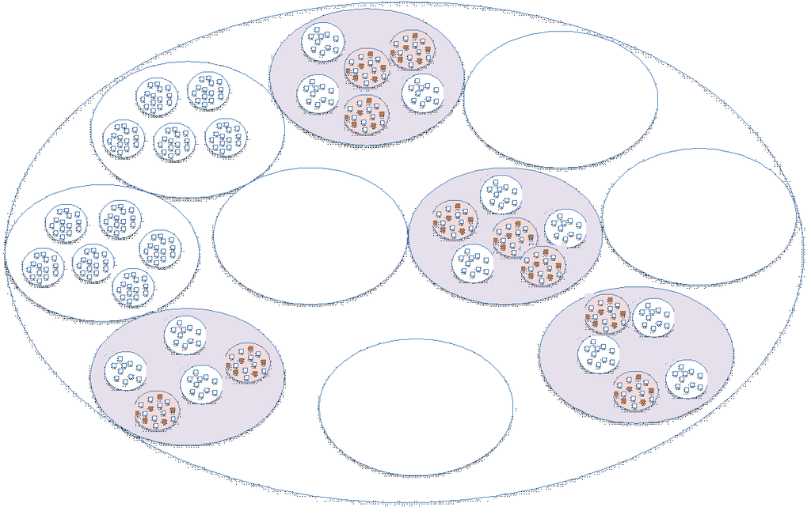

### Oluşumsal (formative) ve Yansıtıcı (reflective) ortalamalar

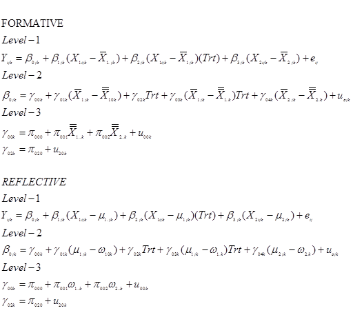

### Problem ve Çözüm

1. Problem: Yansıtıcı ortalamaların kullanılması gereken durumlarda, bir diğer ifade ile örnekleme dayalı hatanın (sampling error) düzeltilmesi gerektiğinde, mevcut yazlımlar iki düzey için örtük ortalama hesaplayabilmelerine rağmen üçüncü (ve devamı) düzey için örtük ortalama hesaplamamaktadır.
2. Çözüm: Croon & van Veldhoven (2007), Ludtke et al. (2008), Raudenbush & Bryk (2002) ve Shin & Raudenbush (2010) tarafından verilen iki düzeyde örtük ortalama hesaplanışlarını inceleyerek, üçüncü düzey için örtük ortalama hesaplamak.

### Sonuçlar

Tek tasarı 1000 replikasyon sonuçları

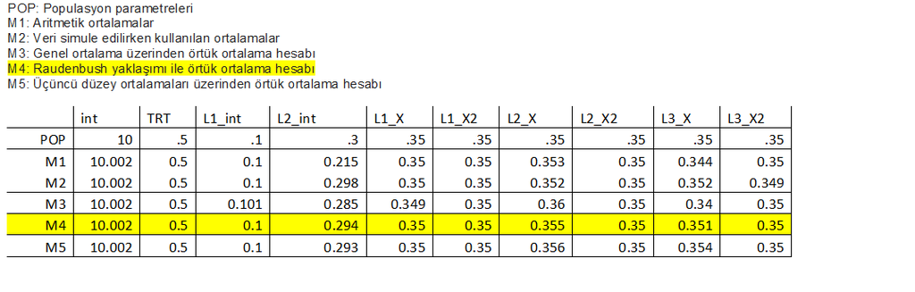

### Referans

Croon, M. A., & van Veldhoven, M. J. P. M. (2007). Predicting group-level outcome variables from variables measured at the individual level: A latent variable multilevel model. *Psychological Methods, 12*, 45-57. doi:10.1037/1082-989X.12.1.45

Ludtke, O., Marsh, H. W., Robitzsch, A., Trautwein, U., Asparouhov, T., & Muthen, B. (2008). The multilevel latent covariate model: A new, more reliable approach to group-level effects in contextual studies. *Psychological Methods, 13*, 203-229. doi:10.1037/a0012869

Raudenbush, S. W., & Bryk, A. S. (2002). *Hierarchical linear models: Applications and data analysis methods.* Thousand Oaks, CA: Sage

Shin, Y., & Raudenbush, S. W. (2010). A latent cluster-mean approach to the contextual effects model with missing data. *Journal of Educational and Behavioral Statistics, 35*(1), 26-53. doi:10.3102/1076998609345252